# Module Seven Activity

For the module seven activity, you will identify relevant data and write Python code to generate visualizations and interpret insights from the provided data set. Professionals in data-driven fields must not only interpret data but also gather, analyze, and present it in meaningful and actionable ways. This activity allows you to practice these essential skills by working through the complete exploratory data analysis (EDA) process.

*Note:* there are two parts to this assignment. Part One is the coding activity. Part Two is the written report.

Once your code is complete, you will download this notebook as an HTML file by clicking **File**, then **Download As**, then **HTML (.html)** from the Jupyter menu bar. Validate that your code, output, and all visualizations (rendered as images using the display() function) are visible in the html file before submission.

*Missing Blocks:* Ensure that you have clicked **Run** for all blocks before downloading as an HTML file or the block may be missing from your submission. **Images** must be called using the *display()* function, for example: **display(Image(filename="output/{image_name}.png"))**

Specifically, you must address the items from the rubric criteria.

### Part One: Python Code

In this part, you will write Python code to analyze the data and generate visualizations that explore trends.

#### Create multiple, distinct visualizations that explore different aspects of the data using Python Libraries.

Include the following:

- Code comments explaining each step of your analysis

### Part Two: Report

In this part, you will write a reflection to explain the insights gained from your analysis and visualizations. *This part is to be completed in a word document, using the output here to answer the topics.*

- Explain the trends, differences, or outliers you observed in the data.
- Describe any disparities or patterns that may be relevant to the nonprofit’s goals.
- Write a summary of what the data suggests about transit usage across neighborhoods.
- Explain how the visualizations support your conclusions.
- Discuss how your findings could inform the nonprofit’s decision-making or strategy.
- Describe the importance of data-driven insights in addressing real-world challenges.

*To Begin:* This Python template program has been broken down into segments as a guide for what steps you should do at a minimum to complete this activity. Look for the **# To Do:** comments. These are placeholders for you to provide Python code segments. Fill out all **# To Do:** code segments to complete this program.  
*Once Complete:* Execute a "Kernel restart and run all" to verify that all your code works as a single unit by clicking **Kernel**, then **Restart & Run All** before downloading as html.

*Hint:* If you need to install additional packages, see one of the earlier modules on how to configure and call a requirements.txt file.

## Import the Required Packages

```python
import pandas as pd
import matplotlib.pyplot as plt
import seaborn as sns
import os
import matplotlib.image as mpimg

from IPython.display import Image, display # for image rendering in html output
```

# Part One: Python Code

*Reminder:* Ensure that you add code comments explaining each step of your analysis.

## Define the file path for the dataset

```python
data_path = "data/Feb_2025_Complete_Monthly_Ridership.csv"
```

## Loading the dataset

```python
df = pd.read_csv(data_path)
```

## Create an output folder if it doesn't already exist

```python
output_folder = "output"
os.makedirs(output_folder, exist_ok=True)
```

## Display Dataset Information

```python
print("Dataset Overview:")
df.head()
```

```
Dataset Overview:
```

|  | NTD ID | Legacy NTD ID | Agency | Mode | TOS | 3 Mode | Mode/Type of Service Status | Reporter Type | Organization Type | HQ City | ... | Last Closed Report Year | Last Closed FY End Month | Last Closed FY End Year | Passenger Miles FY | Unlinked Passenger Trips FY | Avg Trip Length FY | Fares FY | Operating Expenses FY | Avg Cost Per Trip FY | Avg Fares Per Trip FY |
| --- | --- | --- | --- | --- | --- | --- | --- | --- | --- | --- | --- | --- | --- | --- | --- | --- | --- | --- | --- | --- | --- |
| 0 | 1 | 0001 | King County | DR | PT | Bus | Active | Full Reporter | City, County or Local Government Unit or Depar... | SEATTLE | ... | 2023.0 | 12.0 | 2023.0 | 6,470,644 | 888,663 | 7.0 | $816,892.00 | $72,095,003.00 | $81.13 | $0.92 |
| 1 | 1 | 0001 | King County | DR | TX | Bus | Active | Full Reporter | City, County or Local Government Unit or Depar... | SEATTLE | ... | 2023.0 | 12.0 | 2023.0 | 1,509,526 | 121,496 | 12.0 | $105,605.00 | $5,658,724.00 | $46.58 | $0.87 |
| 2 | 1 | 0001 | King County | FB | DO | Ferry | Active | Full Reporter | City, County or Local Government Unit or Depar... | SEATTLE | ... | 2023.0 | 12.0 | 2023.0 | 1,479,694 | 399,687 | 4.0 | $1,493,280.00 | $8,625,721.00 | $21.58 | $3.74 |
| 3 | 1 | 0001 | King County | LR | DO | Rail | Inactive | Full Reporter | City, County or Local Government Unit or Depar... | SEATTLE | ... | 2011.0 | 12.0 | 2011.0 | 471,587 | 520,933 | 1.0 | $288,470.00 | $2,281,393.00 | $4.38 | $0.55 |
| 4 | 1 | 0001 | King County | MB | DO | Bus | Active | Full Reporter | City, County or Local Government Unit or Depar... | SEATTLE | ... | 2023.0 | 12.0 | 2023.0 | 244,710,079 | 63,485,248 | 4.0 | $60,386,305.00 | $710,359,423.00 | $11.19 | $0.95 |

5 rows × 27 columns

```python
print("Column Names:")
df.columns
```

```
Column Names:
```

```
Index(['NTD ID', 'Legacy NTD ID', 'Agency', 'Mode', 'TOS', '3 Mode',
       'Mode/Type of Service Status', 'Reporter Type', 'Organization Type',
       'HQ City', 'HQ State', 'UACE CD', 'UZA Name', 'UZA SQ Miles',
       'UZA Population', 'Service Area Population', 'Service Area SQ Miles',
       'Last Closed Report Year', 'Last Closed FY End Month',
       'Last Closed FY End Year', 'Passenger Miles FY',
       'Unlinked Passenger Trips FY', 'Avg Trip Length FY', 'Fares FY',
       'Operating Expenses FY', 'Avg Cost Per Trip FY',
       'Avg Fares Per Trip FY'],
      dtype='object')
```

```python
neighborhoods = ["King County", "City of Longview", "Spokane Transit Authority"]
neighborhoods_df = df[df['Agency'].isin(neighborhoods)].copy()
```

```python
# Clean and convert UZA SQ Miles
neighborhoods_df['UZA SQ Miles'] = pd.to_numeric(
    neighborhoods_df['UZA SQ Miles'].astype(str).str.replace(',', ''),
    errors='coerce', downcast='float'
)

# Clean and convert Year/Month columns
for col in ['Last Closed Report Year', 'Last Closed FY End Month', 'Last Closed FY End Year']:
    neighborhoods_df[col] = pd.to_numeric(neighborhoods_df[col], errors='coerce', downcast='unsigned')

# Clean and convert Ridership/Distance columns
neighborhoods_df['Passenger Miles FY'] = pd.to_numeric(
    neighborhoods_df['Passenger Miles FY'].astype(str).str.replace(',', ''),
    errors='coerce', downcast='unsigned'
)
neighborhoods_df['Unlinked Passenger Trips FY'] = pd.to_numeric(
    neighborhoods_df['Unlinked Passenger Trips FY'].astype(str).str.replace(',', ''),
    errors='coerce', downcast='unsigned'
)

# Clean and convert Financial columns (removing both commas and dollar signs)
financial_cols = ['Fares FY', 'Operating Expenses FY', 'Avg Cost Per Trip FY', 'Avg Fares Per Trip FY']
for col in financial_cols:
    neighborhoods_df[col] = pd.to_numeric(
        neighborhoods_df[col].astype(str).str.replace(',', '').str.replace('$', ''),
        errors='coerce', downcast='float'
    )
```

## Generate, Save, and Output Visualizations

*Example Visualizations:* The three visualization placeholders below are example visualization placeholders for the data using a provided template. These are simple example frameworks that you may use, but you may, and are encouraged to develop your own visualizations that you will then explain how the selected visualizations support your conclusions in the part two report.

In accordance with the scenario, three neighborhoods for evaluation are: King County, City of Longview, and Spokane Transit Authority which have been listed in the neighborhoods variable above.

This is an example visualization you can generate. You may implement a chart and assessment of your choosing in lieu of this placeholder.

#### At a minimum include the following actions:

- Add title and axis labels
- Save the plot to a png file in the 'output' folder
- Use the display() function to render the generated png image in the html output
- Comments explaining each step of your analysis

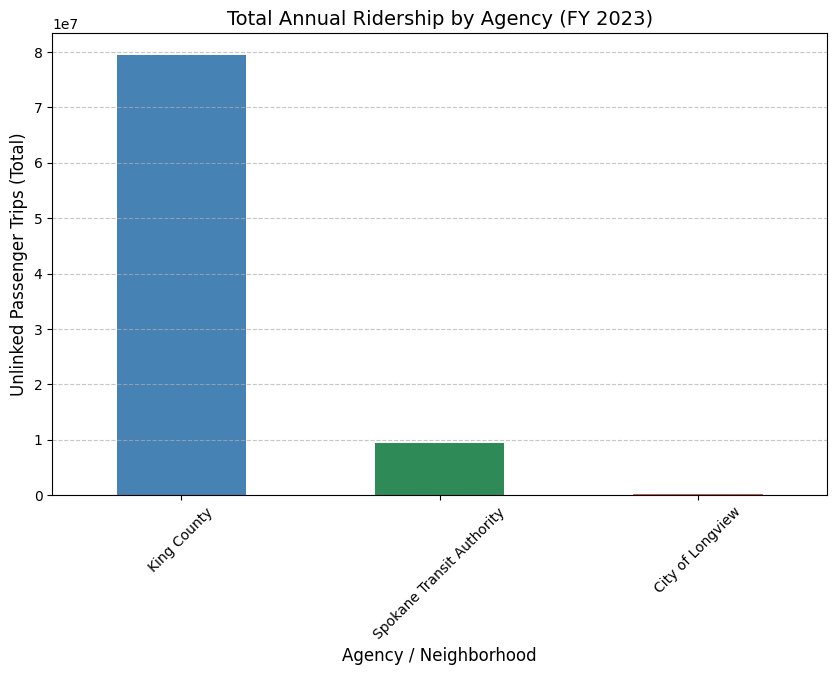

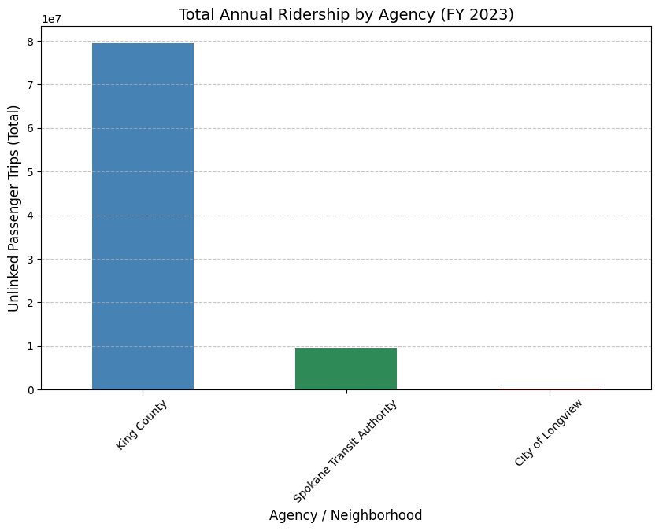

```python
# Group ridership data by Agency and calculate the total trips
agency_ridership = neighborhoods_df.groupby('Agency')['Unlinked Passenger Trips FY'].sum().sort_values(ascending=False)

# Set the figure size for the plot
plt.figure(figsize=(10, 6))

# Create a bar chart using a simple color palette for the three agencies
agency_ridership.plot(kind='bar', color=['steelblue', 'seagreen', 'indianred'])

# Add the title and axis labels for clarity
plt.title('Total Annual Ridership by Agency (FY 2023)', fontsize=14)
plt.xlabel('Agency / Neighborhood', fontsize=12)
plt.ylabel('Unlinked Passenger Trips (Total)', fontsize=12)

# Format the x-axis ticks and add a background grid
plt.xticks(rotation=45)
plt.grid(axis='y', linestyle='--', alpha=0.7)

# Define the file path and save the visualization to the output folder
line_path = os.path.join(output_folder, "ridership_simple.png")
plt.savefig(line_path, bbox_inches='tight')

# Render the generated image in the output
display(Image(line_path))
```

This is an example visualization you can generate. You may implement a chart and assessment of your choosing in lieu of this placeholder.

#### At a minimum include the following actions:

- Add title and axis labels
- Save the plot to a png file in the 'output' folder
- Use the display() function to render the generated png image in the html output
- Comments explaining each step of your analysis

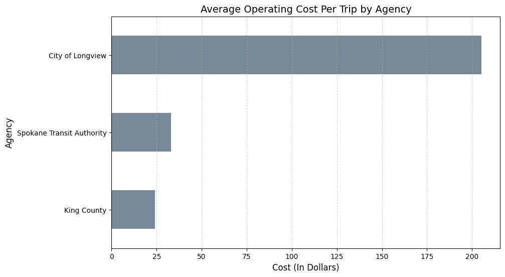

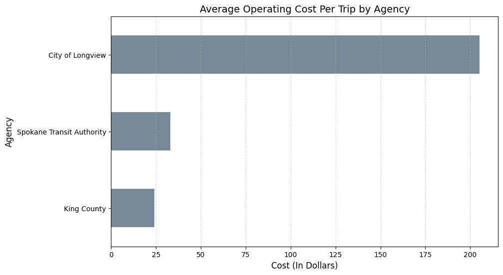

```python
# Group by Agency to find the mean average cost per trip
avg_cost = neighborhoods_df.groupby('Agency')['Avg Cost Per Trip FY'].mean().sort_values()

# Initialize the plot with a horizontal bar chart and neutral color
plt.figure(figsize=(10, 6))
avg_cost.plot(kind='barh', color='lightslategray')

# Add the title and axis labels for the cost analysis
plt.title('Average Operating Cost Per Trip by Agency', fontsize=14)
plt.xlabel('Cost (In Dollars)', fontsize=12)
plt.ylabel('Agency', fontsize=12)

# Add a vertical grid to improve readability of the dollar amounts
plt.grid(axis='x', linestyle='--', alpha=0.5)

# Define the file path and save the efficiency plot to the output folder
bar_path = os.path.join(output_folder, "efficiency_simple.png")
plt.savefig(bar_path, bbox_inches='tight')

# Render the final image in the output
display(Image(bar_path))
```

### Visualization 3: Scatterplot of ridership vs population

This is an example visualization you can generate. You may implement a chart and assessment of your choosing in lieu of this placeholder.

#### At a minimum include the following actions:

- Add title and axis labels
- Save the plot to a png file in the 'output' folder
- Use the display() function to render the generated png image in the html output
- Comments explaining each step of your analysis

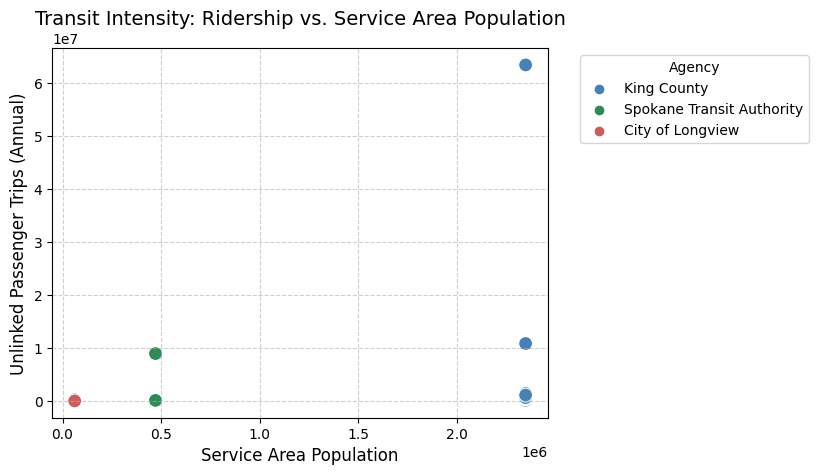

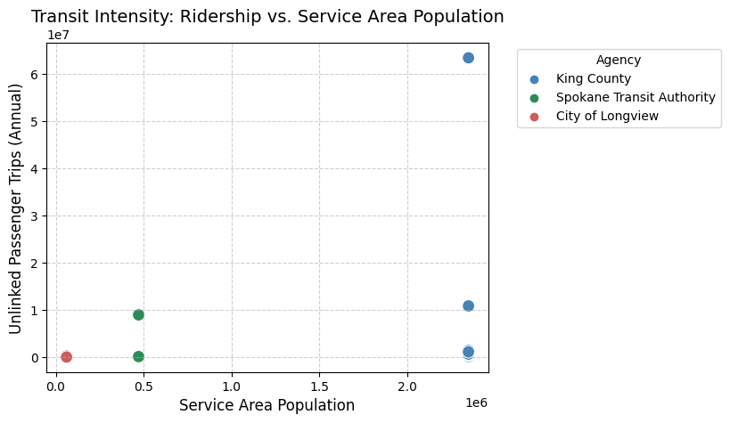

```python
# We use Seaborn for the scatterplot to easily handle agency-based coloring
scatter_plot = sns.scatterplot(
    data=neighborhoods_df,
    x='Service Area Population',
    y='Unlinked Passenger Trips FY',
    hue='Agency',
    s=100, # Marker size for visibility
    palette=['steelblue', 'seagreen', 'indianred']
)

# Adding descriptive titles and labels
plt.title('Transit Intensity: Ridership vs. Service Area Population', fontsize=14)
plt.xlabel('Service Area Population', fontsize=12)
plt.ylabel('Unlinked Passenger Trips (Annual)', fontsize=12)

# Improving readability with a grid and legend placement
plt.grid(True, linestyle='--', alpha=0.6)
plt.legend(title='Agency', bbox_to_anchor=(1.05, 1), loc='upper left')

# Define path, save to the output folder, and display the result
scatter_path = os.path.join(output_folder, "ridership_vs_population.png")
plt.savefig(scatter_path, bbox_inches='tight')

# Render the image in the output
display(Image(scatter_path))
```